# Risk Factor Analysis

## Outcome Variable

**Outcome Variable:** ever_stunted

## Predictor Variables

**Intervention Variable:** born_stunted

**Adjustment Set:**

- arm
- sex
- W_mage
- meducyrs
- feducyrs
- hhwealth_quart
- vagbrth
- W_nrooms
- month
- brthmon
- W_parity
- impfloor
- impsan
- delta_W_mage
- delta_meducyrs
- delta_feducyrs
- delta_hhwealth_quart
- delta_vagbrth
- delta_W_nrooms
- delta_month
- delta_brthmon
- delta_W_parity
- delta_impfloor
- delta_impsan

## Stratifying Variables

The analysis was stratified on these variable(s):

- agecat
- studyid
- country

## Data Summary

| agecat | studyid | country | born_stunted | ever_stunted | n_cell | n |
| --- | --- | --- | --- | --- | --- | --- |
| 0-3 months | ki0047075b-MAL-ED | BANGLADESH | 0 | 0 | 184 | 244 |
| 0-3 months | ki0047075b-MAL-ED | BANGLADESH | 0 | 1 | 28 | 244 |
| 0-3 months | ki0047075b-MAL-ED | BANGLADESH | 1 | 0 | 32 | 244 |
| 0-3 months | ki0047075b-MAL-ED | BANGLADESH | 1 | 1 | 0 | 244 |
| 0-3 months | ki0047075b-MAL-ED | BRAZIL | 0 | 0 | 156 | 183 |
| 0-3 months | ki0047075b-MAL-ED | BRAZIL | 0 | 1 | 13 | 183 |
| 0-3 months | ki0047075b-MAL-ED | BRAZIL | 1 | 0 | 14 | 183 |
| 0-3 months | ki0047075b-MAL-ED | BRAZIL | 1 | 1 | 0 | 183 |
| 0-3 months | ki0047075b-MAL-ED | INDIA | 0 | 0 | 151 | 204 |
| 0-3 months | ki0047075b-MAL-ED | INDIA | 0 | 1 | 23 | 204 |
| 0-3 months | ki0047075b-MAL-ED | INDIA | 1 | 0 | 30 | 204 |
| 0-3 months | ki0047075b-MAL-ED | INDIA | 1 | 1 | 0 | 204 |
| 0-3 months | ki0047075b-MAL-ED | NEPAL | 0 | 0 | 147 | 168 |
| 0-3 months | ki0047075b-MAL-ED | NEPAL | 0 | 1 | 7 | 168 |
| 0-3 months | ki0047075b-MAL-ED | NEPAL | 1 | 0 | 14 | 168 |
| 0-3 months | ki0047075b-MAL-ED | NEPAL | 1 | 1 | 0 | 168 |
| 0-3 months | ki0047075b-MAL-ED | PERU | 0 | 0 | 195 | 282 |
| 0-3 months | ki0047075b-MAL-ED | PERU | 0 | 1 | 61 | 282 |
| 0-3 months | ki0047075b-MAL-ED | PERU | 1 | 0 | 26 | 282 |
| 0-3 months | ki0047075b-MAL-ED | PERU | 1 | 1 | 0 | 282 |
| 0-3 months | ki0047075b-MAL-ED | SOUTH AFRICA | 0 | 0 | 192 | 258 |
| 0-3 months | ki0047075b-MAL-ED | SOUTH AFRICA | 0 | 1 | 40 | 258 |
| 0-3 months | ki0047075b-MAL-ED | SOUTH AFRICA | 1 | 0 | 26 | 258 |
| 0-3 months | ki0047075b-MAL-ED | SOUTH AFRICA | 1 | 1 | 0 | 258 |
| 0-3 months | ki0047075b-MAL-ED | TANZANIA, UNITED REPUBLIC OF | 0 | 0 | 110 | 145 |
| 0-3 months | ki0047075b-MAL-ED | TANZANIA, UNITED REPUBLIC OF | 0 | 1 | 18 | 145 |
| 0-3 months | ki0047075b-MAL-ED | TANZANIA, UNITED REPUBLIC OF | 1 | 0 | 17 | 145 |
| 0-3 months | ki0047075b-MAL-ED | TANZANIA, UNITED REPUBLIC OF | 1 | 1 | 0 | 145 |
| 0-3 months | ki1000108-CMC-V-BCS-2002 | INDIA | 0 | 0 | 51 | 84 |
| 0-3 months | ki1000108-CMC-V-BCS-2002 | INDIA | 0 | 1 | 22 | 84 |

[output cut: 410 more lines]

The following strata were considered:

- agecat: 0-3 months, studyid: ki0047075b-MAL-ED, country: BANGLADESH
- agecat: 0-3 months, studyid: ki0047075b-MAL-ED, country: BRAZIL
- agecat: 0-3 months, studyid: ki0047075b-MAL-ED, country: INDIA
- agecat: 0-3 months, studyid: ki0047075b-MAL-ED, country: NEPAL
- agecat: 0-3 months, studyid: ki0047075b-MAL-ED, country: PERU
- agecat: 0-3 months, studyid: ki0047075b-MAL-ED, country: SOUTH AFRICA
- agecat: 0-3 months, studyid: ki0047075b-MAL-ED, country: TANZANIA, UNITED REPUBLIC OF
- agecat: 0-3 months, studyid: ki1000108-CMC-V-BCS-2002, country: INDIA
- agecat: 0-3 months, studyid: ki1000108-IRC, country: INDIA
- agecat: 0-3 months, studyid: ki1000109-EE, country: PAKISTAN
- agecat: 0-3 months, studyid: ki1000109-ResPak, country: PAKISTAN
- agecat: 0-3 months, studyid: ki1000304b-SAS-CompFeed, country: INDIA
- agecat: 0-3 months, studyid: ki1017093-NIH-Birth, country: BANGLADESH
- agecat: 0-3 months, studyid: ki1017093b-PROVIDE, country: BANGLADESH
- agecat: 0-3 months, studyid: ki1017093c-NIH-Crypto, country: BANGLADESH
- agecat: 0-3 months, studyid: ki1101329-Keneba, country: GAMBIA
- agecat: 0-3 months, studyid: ki1114097-CMIN, country: BANGLADESH
- agecat: 0-3 months, studyid: ki1114097-CMIN, country: BRAZIL
- agecat: 0-3 months, studyid: ki1114097-CMIN, country: GUINEA-BISSAU
- agecat: 0-3 months, studyid: ki1114097-CMIN, country: PERU
- agecat: 0-3 months, studyid: ki1114097-CONTENT, country: PERU
- agecat: 0-3 months, studyid: ki1119695-PROBIT, country: BELARUS
- agecat: 0-3 months, studyid: ki1126311-ZVITAMBO, country: ZIMBABWE
- agecat: 0-3 months, studyid: ki1135781-COHORTS, country: GUATEMALA
- agecat: 0-3 months, studyid: ki1135781-COHORTS, country: INDIA
- agecat: 0-3 months, studyid: ki1135781-COHORTS, country: PHILIPPINES
- agecat: 0-3 months, studyid: kiGH5241-JiVitA-3, country: BANGLADESH
- agecat: 0-3 months, studyid: kiGH5241-JiVitA-4, country: BANGLADESH
- agecat: 12-24 months, studyid: ki0047075b-MAL-ED, country: BANGLADESH
- agecat: 12-24 months, studyid: ki0047075b-MAL-ED, country: BRAZIL
- agecat: 12-24 months, studyid: ki0047075b-MAL-ED, country: INDIA
- agecat: 12-24 months, studyid: ki0047075b-MAL-ED, country: NEPAL
- agecat: 12-24 months, studyid: ki0047075b-MAL-ED, country: PERU
- agecat: 12-24 months, studyid: ki0047075b-MAL-ED, country: SOUTH AFRICA
- agecat: 12-24 months, studyid: ki0047075b-MAL-ED, country: TANZANIA, UNITED REPUBLIC OF
- agecat: 12-24 months, studyid: ki1000108-CMC-V-BCS-2002, country: INDIA
- agecat: 12-24 months, studyid: ki1000108-IRC, country: INDIA
- agecat: 12-24 months, studyid: ki1000109-EE, country: PAKISTAN
- agecat: 12-24 months, studyid: ki1000109-ResPak, country: PAKISTAN
- agecat: 12-24 months, studyid: ki1000304b-SAS-CompFeed, country: INDIA
- agecat: 12-24 months, studyid: ki1017093-NIH-Birth, country: BANGLADESH
- agecat: 12-24 months, studyid: ki1017093b-PROVIDE, country: BANGLADESH
- agecat: 12-24 months, studyid: ki1017093c-NIH-Crypto, country: BANGLADESH
- agecat: 12-24 months, studyid: ki1101329-Keneba, country: GAMBIA
- agecat: 12-24 months, studyid: ki1114097-CMIN, country: BANGLADESH
- agecat: 12-24 months, studyid: ki1114097-CMIN, country: BRAZIL
- agecat: 12-24 months, studyid: ki1114097-CMIN, country: GUINEA-BISSAU
- agecat: 12-24 months, studyid: ki1114097-CMIN, country: PERU
- agecat: 12-24 months, studyid: ki1114097-CONTENT, country: PERU
- agecat: 12-24 months, studyid: ki1119695-PROBIT, country: BELARUS
- agecat: 12-24 months, studyid: ki1126311-ZVITAMBO, country: ZIMBABWE
- agecat: 12-24 months, studyid: ki1135781-COHORTS, country: GUATEMALA
- agecat: 12-24 months, studyid: ki1135781-COHORTS, country: PHILIPPINES
- agecat: 12-24 months, studyid: kiGH5241-JiVitA-3, country: BANGLADESH
- agecat: 12-24 months, studyid: kiGH5241-JiVitA-4, country: BANGLADESH
- agecat: 3-6 months, studyid: ki0047075b-MAL-ED, country: BANGLADESH
- agecat: 3-6 months, studyid: ki0047075b-MAL-ED, country: BRAZIL
- agecat: 3-6 months, studyid: ki0047075b-MAL-ED, country: INDIA
- agecat: 3-6 months, studyid: ki0047075b-MAL-ED, country: NEPAL
- agecat: 3-6 months, studyid: ki0047075b-MAL-ED, country: PERU
- agecat: 3-6 months, studyid: ki0047075b-MAL-ED, country: SOUTH AFRICA
- agecat: 3-6 months, studyid: ki0047075b-MAL-ED, country: TANZANIA, UNITED REPUBLIC OF
- agecat: 3-6 months, studyid: ki1000108-CMC-V-BCS-2002, country: INDIA
- agecat: 3-6 months, studyid: ki1000108-IRC, country: INDIA
- agecat: 3-6 months, studyid: ki1000109-EE, country: PAKISTAN
- agecat: 3-6 months, studyid: ki1000109-ResPak, country: PAKISTAN
- agecat: 3-6 months, studyid: ki1000304b-SAS-CompFeed, country: INDIA
- agecat: 3-6 months, studyid: ki1017093-NIH-Birth, country: BANGLADESH
- agecat: 3-6 months, studyid: ki1017093b-PROVIDE, country: BANGLADESH
- agecat: 3-6 months, studyid: ki1017093c-NIH-Crypto, country: BANGLADESH
- agecat: 3-6 months, studyid: ki1101329-Keneba, country: GAMBIA
- agecat: 3-6 months, studyid: ki1114097-CMIN, country: BANGLADESH
- agecat: 3-6 months, studyid: ki1114097-CMIN, country: BRAZIL
- agecat: 3-6 months, studyid: ki1114097-CMIN, country: GUINEA-BISSAU
- agecat: 3-6 months, studyid: ki1114097-CMIN, country: PERU
- agecat: 3-6 months, studyid: ki1114097-CONTENT, country: PERU
- agecat: 3-6 months, studyid: ki1119695-PROBIT, country: BELARUS
- agecat: 3-6 months, studyid: ki1126311-ZVITAMBO, country: ZIMBABWE
- agecat: 3-6 months, studyid: ki1135781-COHORTS, country: GUATEMALA
- agecat: 3-6 months, studyid: ki1135781-COHORTS, country: PHILIPPINES
- agecat: 3-6 months, studyid: kiGH5241-JiVitA-3, country: BANGLADESH
- agecat: 3-6 months, studyid: kiGH5241-JiVitA-4, country: BANGLADESH
- agecat: 6-12 months, studyid: ki0047075b-MAL-ED, country: BANGLADESH
- agecat: 6-12 months, studyid: ki0047075b-MAL-ED, country: BRAZIL
- agecat: 6-12 months, studyid: ki0047075b-MAL-ED, country: INDIA
- agecat: 6-12 months, studyid: ki0047075b-MAL-ED, country: NEPAL
- agecat: 6-12 months, studyid: ki0047075b-MAL-ED, country: PERU
- agecat: 6-12 months, studyid: ki0047075b-MAL-ED, country: SOUTH AFRICA
- agecat: 6-12 months, studyid: ki0047075b-MAL-ED, country: TANZANIA, UNITED REPUBLIC OF
- agecat: 6-12 months, studyid: ki1000108-CMC-V-BCS-2002, country: INDIA
- agecat: 6-12 months, studyid: ki1000108-IRC, country: INDIA
- agecat: 6-12 months, studyid: ki1000109-EE, country: PAKISTAN
- agecat: 6-12 months, studyid: ki1000109-ResPak, country: PAKISTAN
- agecat: 6-12 months, studyid: ki1000304b-SAS-CompFeed, country: INDIA
- agecat: 6-12 months, studyid: ki1017093-NIH-Birth, country: BANGLADESH
- agecat: 6-12 months, studyid: ki1017093b-PROVIDE, country: BANGLADESH
- agecat: 6-12 months, studyid: ki1017093c-NIH-Crypto, country: BANGLADESH
- agecat: 6-12 months, studyid: ki1101329-Keneba, country: GAMBIA
- agecat: 6-12 months, studyid: ki1114097-CMIN, country: BANGLADESH
- agecat: 6-12 months, studyid: ki1114097-CMIN, country: BRAZIL
- agecat: 6-12 months, studyid: ki1114097-CMIN, country: GUINEA-BISSAU
- agecat: 6-12 months, studyid: ki1114097-CMIN, country: PERU
- agecat: 6-12 months, studyid: ki1114097-CONTENT, country: PERU
- agecat: 6-12 months, studyid: ki1119695-PROBIT, country: BELARUS
- agecat: 6-12 months, studyid: ki1126311-ZVITAMBO, country: ZIMBABWE
- agecat: 6-12 months, studyid: ki1135781-COHORTS, country: GUATEMALA
- agecat: 6-12 months, studyid: ki1135781-COHORTS, country: INDIA
- agecat: 6-12 months, studyid: ki1135781-COHORTS, country: PHILIPPINES
- agecat: 6-12 months, studyid: kiGH5241-JiVitA-3, country: BANGLADESH
- agecat: 6-12 months, studyid: kiGH5241-JiVitA-4, country: BANGLADESH

### Dropped Strata

Some strata were dropped due to rare outcomes:

- agecat: 0-3 months, studyid: ki0047075b-MAL-ED, country: BANGLADESH
- agecat: 0-3 months, studyid: ki0047075b-MAL-ED, country: BRAZIL
- agecat: 0-3 months, studyid: ki0047075b-MAL-ED, country: INDIA
- agecat: 0-3 months, studyid: ki0047075b-MAL-ED, country: NEPAL
- agecat: 0-3 months, studyid: ki0047075b-MAL-ED, country: PERU
- agecat: 0-3 months, studyid: ki0047075b-MAL-ED, country: SOUTH AFRICA
- agecat: 0-3 months, studyid: ki0047075b-MAL-ED, country: TANZANIA, UNITED REPUBLIC OF
- agecat: 0-3 months, studyid: ki1000108-CMC-V-BCS-2002, country: INDIA
- agecat: 0-3 months, studyid: ki1000108-IRC, country: INDIA
- agecat: 0-3 months, studyid: ki1000109-EE, country: PAKISTAN
- agecat: 0-3 months, studyid: ki1000109-ResPak, country: PAKISTAN
- agecat: 0-3 months, studyid: ki1000304b-SAS-CompFeed, country: INDIA
- agecat: 0-3 months, studyid: ki1017093-NIH-Birth, country: BANGLADESH
- agecat: 0-3 months, studyid: ki1017093b-PROVIDE, country: BANGLADESH
- agecat: 0-3 months, studyid: ki1017093c-NIH-Crypto, country: BANGLADESH
- agecat: 0-3 months, studyid: ki1101329-Keneba, country: GAMBIA
- agecat: 0-3 months, studyid: ki1114097-CMIN, country: BANGLADESH
- agecat: 0-3 months, studyid: ki1114097-CMIN, country: BRAZIL
- agecat: 0-3 months, studyid: ki1114097-CMIN, country: GUINEA-BISSAU
- agecat: 0-3 months, studyid: ki1114097-CMIN, country: PERU
- agecat: 0-3 months, studyid: ki1114097-CONTENT, country: PERU
- agecat: 0-3 months, studyid: ki1119695-PROBIT, country: BELARUS
- agecat: 0-3 months, studyid: ki1126311-ZVITAMBO, country: ZIMBABWE
- agecat: 0-3 months, studyid: ki1135781-COHORTS, country: GUATEMALA
- agecat: 0-3 months, studyid: ki1135781-COHORTS, country: INDIA
- agecat: 0-3 months, studyid: ki1135781-COHORTS, country: PHILIPPINES
- agecat: 0-3 months, studyid: kiGH5241-JiVitA-3, country: BANGLADESH
- agecat: 0-3 months, studyid: kiGH5241-JiVitA-4, country: BANGLADESH
- agecat: 3-6 months, studyid: ki0047075b-MAL-ED, country: BRAZIL
- agecat: 3-6 months, studyid: ki0047075b-MAL-ED, country: INDIA
- agecat: 3-6 months, studyid: ki0047075b-MAL-ED, country: NEPAL
- agecat: 3-6 months, studyid: ki0047075b-MAL-ED, country: PERU
- agecat: 3-6 months, studyid: ki0047075b-MAL-ED, country: SOUTH AFRICA
- agecat: 3-6 months, studyid: ki0047075b-MAL-ED, country: TANZANIA, UNITED REPUBLIC OF
- agecat: 3-6 months, studyid: ki1000108-CMC-V-BCS-2002, country: INDIA
- agecat: 3-6 months, studyid: ki1000108-IRC, country: INDIA
- agecat: 3-6 months, studyid: ki1000109-EE, country: PAKISTAN
- agecat: 3-6 months, studyid: ki1000109-ResPak, country: PAKISTAN
- agecat: 3-6 months, studyid: ki1017093-NIH-Birth, country: BANGLADESH
- agecat: 3-6 months, studyid: ki1017093b-PROVIDE, country: BANGLADESH
- agecat: 3-6 months, studyid: ki1114097-CMIN, country: BANGLADESH
- agecat: 3-6 months, studyid: ki1114097-CMIN, country: BRAZIL
- agecat: 3-6 months, studyid: ki1114097-CMIN, country: GUINEA-BISSAU
- agecat: 3-6 months, studyid: ki1114097-CMIN, country: PERU
- agecat: 3-6 months, studyid: ki1114097-CONTENT, country: PERU
- agecat: 3-6 months, studyid: ki1119695-PROBIT, country: BELARUS
- agecat: 3-6 months, studyid: ki1135781-COHORTS, country: GUATEMALA
- agecat: 3-6 months, studyid: kiGH5241-JiVitA-3, country: BANGLADESH
- agecat: 3-6 months, studyid: kiGH5241-JiVitA-4, country: BANGLADESH
- agecat: 6-12 months, studyid: ki0047075b-MAL-ED, country: BRAZIL
- agecat: 6-12 months, studyid: ki0047075b-MAL-ED, country: INDIA
- agecat: 6-12 months, studyid: ki0047075b-MAL-ED, country: NEPAL
- agecat: 6-12 months, studyid: ki0047075b-MAL-ED, country: SOUTH AFRICA
- agecat: 6-12 months, studyid: ki0047075b-MAL-ED, country: TANZANIA, UNITED REPUBLIC OF
- agecat: 6-12 months, studyid: ki1000108-CMC-V-BCS-2002, country: INDIA
- agecat: 6-12 months, studyid: ki1000108-IRC, country: INDIA
- agecat: 6-12 months, studyid: ki1000109-EE, country: PAKISTAN
- agecat: 6-12 months, studyid: ki1000109-ResPak, country: PAKISTAN
- agecat: 6-12 months, studyid: ki1017093b-PROVIDE, country: BANGLADESH
- agecat: 6-12 months, studyid: ki1114097-CMIN, country: BANGLADESH
- agecat: 6-12 months, studyid: ki1114097-CMIN, country: BRAZIL
- agecat: 6-12 months, studyid: ki1114097-CMIN, country: GUINEA-BISSAU
- agecat: 6-12 months, studyid: ki1114097-CMIN, country: PERU
- agecat: 6-12 months, studyid: ki1114097-CONTENT, country: PERU
- agecat: 6-12 months, studyid: ki1135781-COHORTS, country: GUATEMALA
- agecat: 12-24 months, studyid: ki0047075b-MAL-ED, country: BANGLADESH
- agecat: 12-24 months, studyid: ki0047075b-MAL-ED, country: BRAZIL
- agecat: 12-24 months, studyid: ki0047075b-MAL-ED, country: INDIA
- agecat: 12-24 months, studyid: ki0047075b-MAL-ED, country: NEPAL
- agecat: 12-24 months, studyid: ki0047075b-MAL-ED, country: PERU
- agecat: 12-24 months, studyid: ki0047075b-MAL-ED, country: SOUTH AFRICA
- agecat: 12-24 months, studyid: ki0047075b-MAL-ED, country: TANZANIA, UNITED REPUBLIC OF
- agecat: 12-24 months, studyid: ki1000108-CMC-V-BCS-2002, country: INDIA
- agecat: 12-24 months, studyid: ki1000109-EE, country: PAKISTAN
- agecat: 12-24 months, studyid: ki1000109-ResPak, country: PAKISTAN
- agecat: 12-24 months, studyid: ki1017093b-PROVIDE, country: BANGLADESH
- agecat: 12-24 months, studyid: ki1114097-CMIN, country: BANGLADESH
- agecat: 12-24 months, studyid: ki1114097-CMIN, country: BRAZIL
- agecat: 12-24 months, studyid: ki1114097-CMIN, country: GUINEA-BISSAU
- agecat: 12-24 months, studyid: ki1114097-CMIN, country: PERU
- agecat: 12-24 months, studyid: ki1114097-CONTENT, country: PERU
- agecat: 12-24 months, studyid: ki1119695-PROBIT, country: BELARUS
- agecat: 12-24 months, studyid: ki1135781-COHORTS, country: GUATEMALA

## Methods Detail

We’re interested in the causal parameters $E[Y_a]$ for all values of $a \in \mathcal{A}$. These parameters represent the mean outcome if, possibly contrary to fact, we intervened to set all units to have $A=a$. Under the randomization and positivity assumptions, these are identified by the statistical parameters $\psi_a=E_W[E_{Y|A,W}(Y|A=a,W)]$. In addition, we’re interested in the mean of $Y$, $E[Y]$ under no intervention (the observed mean). We will estimate these parameters by using SuperLearner to fit the relevant likelihood factors – $E_{Y|A,W}(Y|A=a,W)$ and $p(A=a|W)$, and then updating our likelihood fit using a joint TMLE.

For unadjusted analyses ($W=\{\}$), initial likelihoods were estimated using Lrnr_glm to estimate the simple $E(Y|A)$ and Lrnr_mean to estimate $p(A)$. For adjusted analyses, a small library containing Lrnr_glmnet, Lrnr_xgboost, and Lrnr_mean was used.

Having estimated these parameters, we will then use the delta method to estimate relative risks and attributable risks relative to a prespecified baseline level of $A$.

# Results Detail

## Results Plots

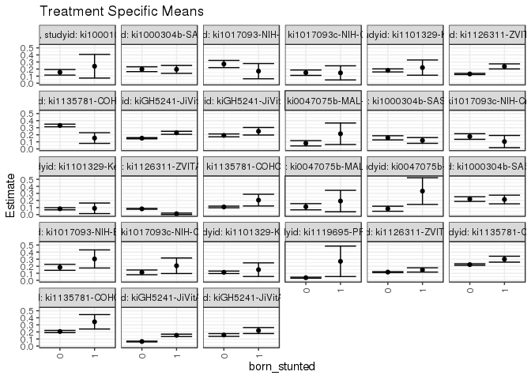

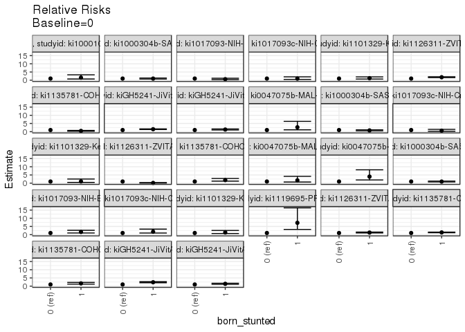

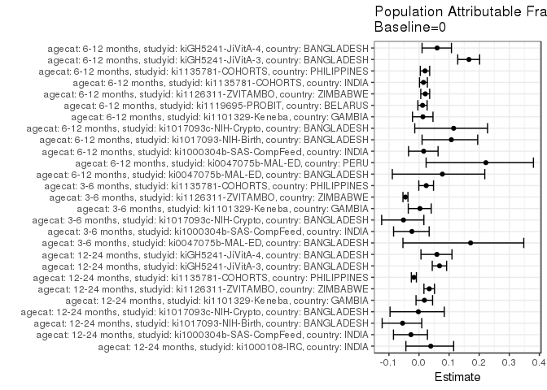

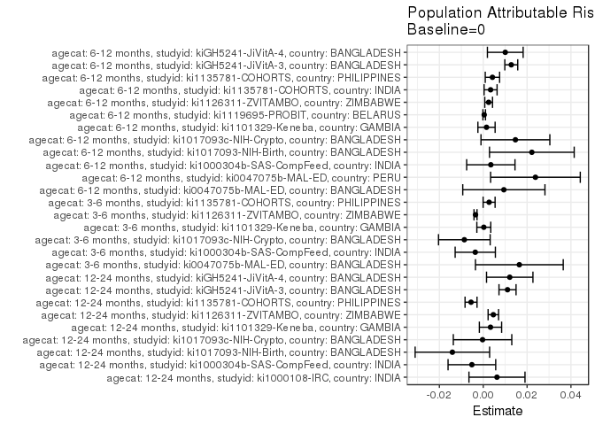

## Results Table

### Parameter: TSM

| agecat | studyid | country | intervention_level | baseline_level | estimate | ci_lower | ci_upper |
| --- | --- | --- | --- | --- | --- | --- | --- |
| 3-6 months | ki0047075b-MAL-ED | BANGLADESH | 0 | NA | 0.0796020 | 0.0421004 | 0.1171036 |
| 3-6 months | ki0047075b-MAL-ED | BANGLADESH | 1 | NA | 0.2142857 | 0.0619687 | 0.3666027 |
| 3-6 months | ki1000304b-SAS-CompFeed | INDIA | 0 | NA | 0.1570079 | 0.1273001 | 0.1867157 |
| 3-6 months | ki1000304b-SAS-CompFeed | INDIA | 1 | NA | 0.1197740 | 0.0792210 | 0.1603271 |
| 3-6 months | ki1017093c-NIH-Crypto | BANGLADESH | 0 | NA | 0.1752874 | 0.1352897 | 0.2152850 |
| 3-6 months | ki1017093c-NIH-Crypto | BANGLADESH | 1 | NA | 0.1041667 | 0.0176391 | 0.1906942 |
| 3-6 months | ki1101329-Keneba | GAMBIA | 0 | NA | 0.0830745 | 0.0679962 | 0.0981528 |
| 3-6 months | ki1101329-Keneba | GAMBIA | 1 | NA | 0.0892857 | 0.0145724 | 0.1639990 |
| 3-6 months | ki1126311-ZVITAMBO | ZIMBABWE | 0 | NA | 0.0817618 | 0.0757197 | 0.0878039 |
| 3-6 months | ki1126311-ZVITAMBO | ZIMBABWE | 1 | NA | 0.0119048 | 0.0015317 | 0.0222779 |
| 3-6 months | ki1135781-COHORTS | PHILIPPINES | 0 | NA | 0.1086450 | 0.0966557 | 0.1206343 |
| 3-6 months | ki1135781-COHORTS | PHILIPPINES | 1 | NA | 0.2051150 | 0.1222684 | 0.2879615 |
| 6-12 months | ki0047075b-MAL-ED | BANGLADESH | 0 | NA | 0.1116751 | 0.0675938 | 0.1557565 |
| 6-12 months | ki0047075b-MAL-ED | BANGLADESH | 1 | NA | 0.1923077 | 0.0404773 | 0.3441381 |
| 6-12 months | ki0047075b-MAL-ED | PERU | 0 | NA | 0.0833333 | 0.0473866 | 0.1192800 |
| 6-12 months | ki0047075b-MAL-ED | PERU | 1 | NA | 0.3333333 | 0.1443604 | 0.5223063 |
| 6-12 months | ki1000304b-SAS-CompFeed | INDIA | 0 | NA | 0.2200037 | 0.1870380 | 0.2529694 |
| 6-12 months | ki1000304b-SAS-CompFeed | INDIA | 1 | NA | 0.2140588 | 0.1524272 | 0.2756905 |
| 6-12 months | ki1017093-NIH-Birth | BANGLADESH | 0 | NA | 0.1842662 | 0.1419490 | 0.2265833 |
| 6-12 months | ki1017093-NIH-Birth | BANGLADESH | 1 | NA | 0.3028914 | 0.1747186 | 0.4310641 |
| 6-12 months | ki1017093c-NIH-Crypto | BANGLADESH | 0 | NA | 0.1128767 | 0.0793081 | 0.1464454 |
| 6-12 months | ki1017093c-NIH-Crypto | BANGLADESH | 1 | NA | 0.2063521 | 0.0963014 | 0.3164027 |
| 6-12 months | ki1101329-Keneba | GAMBIA | 0 | NA | 0.1136364 | 0.0962163 | 0.1310565 |
| 6-12 months | ki1101329-Keneba | GAMBIA | 1 | NA | 0.1509434 | 0.0545274 | 0.2473594 |
| 6-12 months | ki1119695-PROBIT | BELARUS | 0 | NA | 0.0373483 | 0.0298218 | 0.0448749 |
| 6-12 months | ki1119695-PROBIT | BELARUS | 1 | NA | 0.2692308 | 0.0535401 | 0.4849215 |
| 6-12 months | ki1126311-ZVITAMBO | ZIMBABWE | 0 | NA | 0.1166299 | 0.1099313 | 0.1233286 |
| 6-12 months | ki1126311-ZVITAMBO | ZIMBABWE | 1 | NA | 0.1472307 | 0.1167935 | 0.1776678 |
| 6-12 months | ki1135781-COHORTS | INDIA | 0 | NA | 0.2227760 | 0.2117240 | 0.2338279 |
| 6-12 months | ki1135781-COHORTS | INDIA | 1 | NA | 0.2995878 | 0.2575647 | 0.3416109 |
| 6-12 months | ki1135781-COHORTS | PHILIPPINES | 0 | NA | 0.2057964 | 0.1900932 | 0.2214996 |
| 6-12 months | ki1135781-COHORTS | PHILIPPINES | 1 | NA | 0.3432502 | 0.2409818 | 0.4455187 |
| 6-12 months | kiGH5241-JiVitA-3 | BANGLADESH | 0 | NA | 0.0642606 | 0.0589444 | 0.0695768 |
| 6-12 months | kiGH5241-JiVitA-3 | BANGLADESH | 1 | NA | 0.1517064 | 0.1347847 | 0.1686281 |
| 6-12 months | kiGH5241-JiVitA-4 | BANGLADESH | 0 | NA | 0.1566977 | 0.1369768 | 0.1764186 |
| 6-12 months | kiGH5241-JiVitA-4 | BANGLADESH | 1 | NA | 0.2197601 | 0.1773534 | 0.2621667 |
| 12-24 months | ki1000108-IRC | INDIA | 0 | NA | 0.1540881 | 0.1143492 | 0.1938269 |
| 12-24 months | ki1000108-IRC | INDIA | 1 | NA | 0.2400000 | 0.0723419 | 0.4076581 |
| 12-24 months | ki1000304b-SAS-CompFeed | INDIA | 0 | NA | 0.1978423 | 0.1637330 | 0.2319517 |
| 12-24 months | ki1000304b-SAS-CompFeed | INDIA | 1 | NA | 0.1957245 | 0.1392770 | 0.2521721 |
| 12-24 months | ki1017093-NIH-Birth | BANGLADESH | 0 | NA | 0.2714777 | 0.2203055 | 0.3226498 |
| 12-24 months | ki1017093-NIH-Birth | BANGLADESH | 1 | NA | 0.1702128 | 0.0626104 | 0.2778152 |
| 12-24 months | ki1017093c-NIH-Crypto | BANGLADESH | 0 | NA | 0.1483680 | 0.1103670 | 0.1863689 |
| 12-24 months | ki1017093c-NIH-Crypto | BANGLADESH | 1 | NA | 0.1458333 | 0.0458582 | 0.2458085 |
| 12-24 months | ki1101329-Keneba | GAMBIA | 0 | NA | 0.1809023 | 0.1594450 | 0.2023596 |
| 12-24 months | ki1101329-Keneba | GAMBIA | 1 | NA | 0.2206444 | 0.1128183 | 0.3284706 |
| 12-24 months | ki1126311-ZVITAMBO | ZIMBABWE | 0 | NA | 0.1306578 | 0.1223721 | 0.1389436 |
| 12-24 months | ki1126311-ZVITAMBO | ZIMBABWE | 1 | NA | 0.2373999 | 0.2015878 | 0.2732120 |
| 12-24 months | ki1135781-COHORTS | PHILIPPINES | 0 | NA | 0.3318192 | 0.3132345 | 0.3504038 |
| 12-24 months | ki1135781-COHORTS | PHILIPPINES | 1 | NA | 0.1535360 | 0.0782793 | 0.2287926 |
| 12-24 months | kiGH5241-JiVitA-3 | BANGLADESH | 0 | NA | 0.1513536 | 0.1428413 | 0.1598659 |
| 12-24 months | kiGH5241-JiVitA-3 | BANGLADESH | 1 | NA | 0.2280592 | 0.2067753 | 0.2493431 |
| 12-24 months | kiGH5241-JiVitA-4 | BANGLADESH | 0 | NA | 0.1912048 | 0.1705934 | 0.2118162 |
| 12-24 months | kiGH5241-JiVitA-4 | BANGLADESH | 1 | NA | 0.2498410 | 0.1964688 | 0.3032132 |

### Parameter: E(Y)

| agecat | studyid | country | intervention_level | baseline_level | estimate | ci_lower | ci_upper |
| --- | --- | --- | --- | --- | --- | --- | --- |
| 3-6 months | ki0047075b-MAL-ED | BANGLADESH | NA | NA | 0.0960699 | 0.0578190 | 0.1343208 |
| 3-6 months | ki1000304b-SAS-CompFeed | INDIA | NA | NA | 0.1533666 | 0.1270023 | 0.1797309 |
| 3-6 months | ki1017093c-NIH-Crypto | BANGLADESH | NA | NA | 0.1666667 | 0.1299145 | 0.2034189 |
| 3-6 months | ki1101329-Keneba | GAMBIA | NA | NA | 0.0833333 | 0.0685516 | 0.0981151 |
| 3-6 months | ki1126311-ZVITAMBO | ZIMBABWE | NA | NA | 0.0782358 | 0.0724655 | 0.0840061 |
| 3-6 months | ki1135781-COHORTS | PHILIPPINES | NA | NA | 0.1113193 | 0.0993824 | 0.1232563 |
| 6-12 months | ki0047075b-MAL-ED | BANGLADESH | NA | NA | 0.1210762 | 0.0781644 | 0.1639880 |
| 6-12 months | ki0047075b-MAL-ED | PERU | NA | NA | 0.1071429 | 0.0688794 | 0.1454063 |
| 6-12 months | ki1000304b-SAS-CompFeed | INDIA | NA | NA | 0.2234637 | 0.1907158 | 0.2562116 |
| 6-12 months | ki1017093-NIH-Birth | BANGLADESH | NA | NA | 0.2064343 | 0.1653043 | 0.2475643 |
| 6-12 months | ki1017093c-NIH-Crypto | BANGLADESH | NA | NA | 0.1275510 | 0.0944858 | 0.1606163 |
| 6-12 months | ki1101329-Keneba | GAMBIA | NA | NA | 0.1151242 | 0.0979580 | 0.1322903 |
| 6-12 months | ki1119695-PROBIT | BELARUS | NA | NA | 0.0377882 | 0.0302168 | 0.0453595 |
| 6-12 months | ki1126311-ZVITAMBO | ZIMBABWE | NA | NA | 0.1190963 | 0.1125112 | 0.1256814 |
| 6-12 months | ki1135781-COHORTS | INDIA | NA | NA | 0.2261246 | 0.2153393 | 0.2369098 |
| 6-12 months | ki1135781-COHORTS | PHILIPPINES | NA | NA | 0.2099848 | 0.1943978 | 0.2255717 |
| 6-12 months | kiGH5241-JiVitA-3 | BANGLADESH | NA | NA | 0.0770470 | 0.0716324 | 0.0824616 |
| 6-12 months | kiGH5241-JiVitA-4 | BANGLADESH | NA | NA | 0.1667439 | 0.1481671 | 0.1853207 |
| 12-24 months | ki1000108-IRC | INDIA | NA | NA | 0.1603499 | 0.1214616 | 0.1992381 |
| 12-24 months | ki1000304b-SAS-CompFeed | INDIA | NA | NA | 0.1926606 | 0.1608065 | 0.2245146 |
| 12-24 months | ki1017093-NIH-Birth | BANGLADESH | NA | NA | 0.2573964 | 0.2107184 | 0.3040745 |
| 12-24 months | ki1017093c-NIH-Crypto | BANGLADESH | NA | NA | 0.1480519 | 0.1125301 | 0.1835738 |
| 12-24 months | ki1101329-Keneba | GAMBIA | NA | NA | 0.1842105 | 0.1630644 | 0.2053567 |
| 12-24 months | ki1126311-ZVITAMBO | ZIMBABWE | NA | NA | 0.1352599 | 0.1270781 | 0.1434418 |
| 12-24 months | ki1135781-COHORTS | PHILIPPINES | NA | NA | 0.3262495 | 0.3080166 | 0.3444824 |
| 12-24 months | kiGH5241-JiVitA-3 | BANGLADESH | NA | NA | 0.1624278 | 0.1545118 | 0.1703438 |
| 12-24 months | kiGH5241-JiVitA-4 | BANGLADESH | NA | NA | 0.2032864 | 0.1839142 | 0.2226586 |

### Parameter: RR

| agecat | studyid | country | intervention_level | baseline_level | estimate | ci_lower | ci_upper |
| --- | --- | --- | --- | --- | --- | --- | --- |
| 3-6 months | ki0047075b-MAL-ED | BANGLADESH | 0 | 0 | 1.0000000 | 1.0000000 | 1.0000000 |
| 3-6 months | ki0047075b-MAL-ED | BANGLADESH | 1 | 0 | 2.6919643 | 1.1474121 | 6.3156661 |
| 3-6 months | ki1000304b-SAS-CompFeed | INDIA | 0 | 0 | 1.0000000 | 1.0000000 | 1.0000000 |
| 3-6 months | ki1000304b-SAS-CompFeed | INDIA | 1 | 0 | 0.7628535 | 0.5212773 | 1.1163837 |
| 3-6 months | ki1017093c-NIH-Crypto | BANGLADESH | 0 | 0 | 1.0000000 | 1.0000000 | 1.0000000 |
| 3-6 months | ki1017093c-NIH-Crypto | BANGLADESH | 1 | 0 | 0.5942623 | 0.2511085 | 1.4063549 |
| 3-6 months | ki1101329-Keneba | GAMBIA | 0 | 0 | 1.0000000 | 1.0000000 | 1.0000000 |
| 3-6 months | ki1101329-Keneba | GAMBIA | 1 | 0 | 1.0747664 | 0.4565105 | 2.5303312 |
| 3-6 months | ki1126311-ZVITAMBO | ZIMBABWE | 0 | 0 | 1.0000000 | 1.0000000 | 1.0000000 |
| 3-6 months | ki1126311-ZVITAMBO | ZIMBABWE | 1 | 0 | 0.1456035 | 0.0607289 | 0.3490984 |
| 3-6 months | ki1135781-COHORTS | PHILIPPINES | 0 | 0 | 1.0000000 | 1.0000000 | 1.0000000 |
| 3-6 months | ki1135781-COHORTS | PHILIPPINES | 1 | 0 | 1.8879380 | 1.2418706 | 2.8701137 |
| 6-12 months | ki0047075b-MAL-ED | BANGLADESH | 0 | 0 | 1.0000000 | 1.0000000 | 1.0000000 |
| 6-12 months | ki0047075b-MAL-ED | BANGLADESH | 1 | 0 | 1.7220280 | 0.7123459 | 4.1628377 |
| 6-12 months | ki0047075b-MAL-ED | PERU | 0 | 0 | 1.0000000 | 1.0000000 | 1.0000000 |
| 6-12 months | ki0047075b-MAL-ED | PERU | 1 | 0 | 4.0000000 | 1.9619245 | 8.1552579 |
| 6-12 months | ki1000304b-SAS-CompFeed | INDIA | 0 | 0 | 1.0000000 | 1.0000000 | 1.0000000 |
| 6-12 months | ki1000304b-SAS-CompFeed | INDIA | 1 | 0 | 0.9729785 | 0.7475284 | 1.2664230 |
| 6-12 months | ki1017093-NIH-Birth | BANGLADESH | 0 | 0 | 1.0000000 | 1.0000000 | 1.0000000 |
| 6-12 months | ki1017093-NIH-Birth | BANGLADESH | 1 | 0 | 1.6437710 | 1.0153631 | 2.6611005 |
| 6-12 months | ki1017093c-NIH-Crypto | BANGLADESH | 0 | 0 | 1.0000000 | 1.0000000 | 1.0000000 |
| 6-12 months | ki1017093c-NIH-Crypto | BANGLADESH | 1 | 0 | 1.8281190 | 0.9931961 | 3.3649137 |
| 6-12 months | ki1101329-Keneba | GAMBIA | 0 | 0 | 1.0000000 | 1.0000000 | 1.0000000 |
| 6-12 months | ki1101329-Keneba | GAMBIA | 1 | 0 | 1.3283019 | 0.6886707 | 2.5620168 |
| 6-12 months | ki1119695-PROBIT | BELARUS | 0 | 0 | 1.0000000 | 1.0000000 | 1.0000000 |
| 6-12 months | ki1119695-PROBIT | BELARUS | 1 | 0 | 7.2086407 | 3.1819925 | 16.3308055 |
| 6-12 months | ki1126311-ZVITAMBO | ZIMBABWE | 0 | 0 | 1.0000000 | 1.0000000 | 1.0000000 |
| 6-12 months | ki1126311-ZVITAMBO | ZIMBABWE | 1 | 0 | 1.2623748 | 1.0186586 | 1.5644008 |
| 6-12 months | ki1135781-COHORTS | INDIA | 0 | 0 | 1.0000000 | 1.0000000 | 1.0000000 |
| 6-12 months | ki1135781-COHORTS | INDIA | 1 | 0 | 1.3447942 | 1.1591258 | 1.5602029 |
| 6-12 months | ki1135781-COHORTS | PHILIPPINES | 0 | 0 | 1.0000000 | 1.0000000 | 1.0000000 |
| 6-12 months | ki1135781-COHORTS | PHILIPPINES | 1 | 0 | 1.6679115 | 1.2266233 | 2.2679569 |
| 6-12 months | kiGH5241-JiVitA-3 | BANGLADESH | 0 | 0 | 1.0000000 | 1.0000000 | 1.0000000 |
| 6-12 months | kiGH5241-JiVitA-3 | BANGLADESH | 1 | 0 | 2.3607993 | 2.0583839 | 2.7076452 |
| 6-12 months | kiGH5241-JiVitA-4 | BANGLADESH | 0 | 0 | 1.0000000 | 1.0000000 | 1.0000000 |
| 6-12 months | kiGH5241-JiVitA-4 | BANGLADESH | 1 | 0 | 1.4024461 | 1.1253057 | 1.7478407 |
| 12-24 months | ki1000108-IRC | INDIA | 0 | 0 | 1.0000000 | 1.0000000 | 1.0000000 |
| 12-24 months | ki1000108-IRC | INDIA | 1 | 0 | 1.5575510 | 0.7396743 | 3.2797747 |
| 12-24 months | ki1000304b-SAS-CompFeed | INDIA | 0 | 0 | 1.0000000 | 1.0000000 | 1.0000000 |
| 12-24 months | ki1000304b-SAS-CompFeed | INDIA | 1 | 0 | 0.9892955 | 0.7380563 | 1.3260582 |
| 12-24 months | ki1017093-NIH-Birth | BANGLADESH | 0 | 0 | 1.0000000 | 1.0000000 | 1.0000000 |
| 12-24 months | ki1017093-NIH-Birth | BANGLADESH | 1 | 0 | 0.6269863 | 0.3241663 | 1.2126855 |
| 12-24 months | ki1017093c-NIH-Crypto | BANGLADESH | 0 | 0 | 1.0000000 | 1.0000000 | 1.0000000 |
| 12-24 months | ki1017093c-NIH-Crypto | BANGLADESH | 1 | 0 | 0.9829167 | 0.4728118 | 2.0433611 |
| 12-24 months | ki1101329-Keneba | GAMBIA | 0 | 0 | 1.0000000 | 1.0000000 | 1.0000000 |
| 12-24 months | ki1101329-Keneba | GAMBIA | 1 | 0 | 1.2196884 | 0.7376082 | 2.0168427 |
| 12-24 months | ki1126311-ZVITAMBO | ZIMBABWE | 0 | 0 | 1.0000000 | 1.0000000 | 1.0000000 |
| 12-24 months | ki1126311-ZVITAMBO | ZIMBABWE | 1 | 0 | 1.8169588 | 1.5429988 | 2.1395604 |
| 12-24 months | ki1135781-COHORTS | PHILIPPINES | 0 | 0 | 1.0000000 | 1.0000000 | 1.0000000 |
| 12-24 months | ki1135781-COHORTS | PHILIPPINES | 1 | 0 | 0.4627097 | 0.2825160 | 0.7578343 |
| 12-24 months | kiGH5241-JiVitA-3 | BANGLADESH | 0 | 0 | 1.0000000 | 1.0000000 | 1.0000000 |
| 12-24 months | kiGH5241-JiVitA-3 | BANGLADESH | 1 | 0 | 1.5067976 | 1.3485958 | 1.6835578 |
| 12-24 months | kiGH5241-JiVitA-4 | BANGLADESH | 0 | 0 | 1.0000000 | 1.0000000 | 1.0000000 |
| 12-24 months | kiGH5241-JiVitA-4 | BANGLADESH | 1 | 0 | 1.3066669 | 1.0270433 | 1.6624209 |

### Parameter: PAR

| agecat | studyid | country | intervention_level | baseline_level | estimate | ci_lower | ci_upper |
| --- | --- | --- | --- | --- | --- | --- | --- |
| 3-6 months | ki0047075b-MAL-ED | BANGLADESH | 0 | NA | 0.0164679 | -0.0035490 | 0.0364848 |
| 3-6 months | ki1000304b-SAS-CompFeed | INDIA | 0 | NA | -0.0036413 | -0.0128174 | 0.0055347 |
| 3-6 months | ki1017093c-NIH-Crypto | BANGLADESH | 0 | NA | -0.0086207 | -0.0203998 | 0.0031584 |
| 3-6 months | ki1101329-Keneba | GAMBIA | 0 | NA | 0.0002588 | -0.0029177 | 0.0034353 |
| 3-6 months | ki1126311-ZVITAMBO | ZIMBABWE | 0 | NA | -0.0035260 | -0.0042153 | -0.0028367 |
| 3-6 months | ki1135781-COHORTS | PHILIPPINES | 0 | NA | 0.0026744 | -0.0000576 | 0.0054064 |
| 6-12 months | ki0047075b-MAL-ED | BANGLADESH | 0 | NA | 0.0094011 | -0.0093438 | 0.0281460 |
| 6-12 months | ki0047075b-MAL-ED | PERU | 0 | NA | 0.0238095 | 0.0033632 | 0.0442558 |
| 6-12 months | ki1000304b-SAS-CompFeed | INDIA | 0 | NA | 0.0034600 | -0.0075623 | 0.0144823 |
| 6-12 months | ki1017093-NIH-Birth | BANGLADESH | 0 | NA | 0.0221682 | 0.0028525 | 0.0414838 |
| 6-12 months | ki1017093c-NIH-Crypto | BANGLADESH | 0 | NA | 0.0146743 | -0.0010317 | 0.0303803 |
| 6-12 months | ki1101329-Keneba | GAMBIA | 0 | NA | 0.0014878 | -0.0024392 | 0.0054148 |
| 6-12 months | ki1119695-PROBIT | BELARUS | 0 | NA | 0.0004398 | -0.0001460 | 0.0010256 |
| 6-12 months | ki1126311-ZVITAMBO | ZIMBABWE | 0 | NA | 0.0024664 | 0.0006992 | 0.0042335 |
| 6-12 months | ki1135781-COHORTS | INDIA | 0 | NA | 0.0033486 | 0.0003895 | 0.0063077 |
| 6-12 months | ki1135781-COHORTS | PHILIPPINES | 0 | NA | 0.0041883 | 0.0009150 | 0.0074617 |
| 6-12 months | kiGH5241-JiVitA-3 | BANGLADESH | 0 | NA | 0.0127864 | 0.0098394 | 0.0157334 |
| 6-12 months | kiGH5241-JiVitA-4 | BANGLADESH | 0 | NA | 0.0100462 | 0.0018965 | 0.0181958 |
| 12-24 months | ki1000108-IRC | INDIA | 0 | NA | 0.0062618 | -0.0065178 | 0.0190414 |
| 12-24 months | ki1000304b-SAS-CompFeed | INDIA | 0 | NA | -0.0051818 | -0.0160493 | 0.0056857 |
| 12-24 months | ki1017093-NIH-Birth | BANGLADESH | 0 | NA | -0.0140812 | -0.0310666 | 0.0029041 |
| 12-24 months | ki1017093c-NIH-Crypto | BANGLADESH | 0 | NA | -0.0003160 | -0.0136508 | 0.0130187 |
| 12-24 months | ki1101329-Keneba | GAMBIA | 0 | NA | 0.0033082 | -0.0017710 | 0.0083874 |
| 12-24 months | ki1126311-ZVITAMBO | ZIMBABWE | 0 | NA | 0.0046021 | 0.0022152 | 0.0069890 |
| 12-24 months | ki1135781-COHORTS | PHILIPPINES | 0 | NA | -0.0055697 | -0.0083015 | -0.0028378 |
| 12-24 months | kiGH5241-JiVitA-3 | BANGLADESH | 0 | NA | 0.0110742 | 0.0071828 | 0.0149656 |
| 12-24 months | kiGH5241-JiVitA-4 | BANGLADESH | 0 | NA | 0.0120816 | 0.0014968 | 0.0226664 |

### Parameter: PAF

| agecat | studyid | country | intervention_level | baseline_level | estimate | ci_lower | ci_upper |
| --- | --- | --- | --- | --- | --- | --- | --- |
| 3-6 months | ki0047075b-MAL-ED | BANGLADESH | 0 | NA | 0.1714156 | -0.0534323 | 0.3482713 |
| 3-6 months | ki1000304b-SAS-CompFeed | INDIA | 0 | NA | -0.0237426 | -0.0845758 | 0.0336785 |
| 3-6 months | ki1017093c-NIH-Crypto | BANGLADESH | 0 | NA | -0.0517241 | -0.1242551 | 0.0161276 |
| 3-6 months | ki1101329-Keneba | GAMBIA | 0 | NA | 0.0031056 | -0.0357473 | 0.0405010 |
| 3-6 months | ki1126311-ZVITAMBO | ZIMBABWE | 0 | NA | -0.0450690 | -0.0533805 | -0.0368231 |
| 3-6 months | ki1135781-COHORTS | PHILIPPINES | 0 | NA | 0.0240243 | -0.0007158 | 0.0481528 |
| 6-12 months | ki0047075b-MAL-ED | BANGLADESH | 0 | NA | 0.0776462 | -0.0887560 | 0.2186160 |
| 6-12 months | ki0047075b-MAL-ED | PERU | 0 | NA | 0.2222222 | 0.0235864 | 0.3804487 |
| 6-12 months | ki1000304b-SAS-CompFeed | INDIA | 0 | NA | 0.0154836 | -0.0347977 | 0.0633216 |
| 6-12 months | ki1017093-NIH-Birth | BANGLADESH | 0 | NA | 0.1073860 | 0.0101276 | 0.1950885 |
| 6-12 months | ki1017093c-NIH-Crypto | BANGLADESH | 0 | NA | 0.1150466 | -0.0141582 | 0.2277906 |
| 6-12 months | ki1101329-Keneba | GAMBIA | 0 | NA | 0.0129234 | -0.0217417 | 0.0464123 |
| 6-12 months | ki1119695-PROBIT | BELARUS | 0 | NA | 0.0116389 | -0.0038918 | 0.0269293 |
| 6-12 months | ki1126311-ZVITAMBO | ZIMBABWE | 0 | NA | 0.0207091 | 0.0057937 | 0.0354007 |
| 6-12 months | ki1135781-COHORTS | INDIA | 0 | NA | 0.0148087 | 0.0016489 | 0.0277951 |
| 6-12 months | ki1135781-COHORTS | PHILIPPINES | 0 | NA | 0.0199459 | 0.0042659 | 0.0353790 |
| 6-12 months | kiGH5241-JiVitA-3 | BANGLADESH | 0 | NA | 0.1659555 | 0.1287241 | 0.2015959 |
| 6-12 months | kiGH5241-JiVitA-4 | BANGLADESH | 0 | NA | 0.0602491 | 0.0101230 | 0.1078369 |
| 12-24 months | ki1000108-IRC | INDIA | 0 | NA | 0.0390509 | -0.0436581 | 0.1152053 |
| 12-24 months | ki1000304b-SAS-CompFeed | INDIA | 0 | NA | -0.0268959 | -0.0848587 | 0.0279700 |
| 12-24 months | ki1017093-NIH-Birth | BANGLADESH | 0 | NA | -0.0547063 | -0.1225897 | 0.0090721 |
| 12-24 months | ki1017093c-NIH-Crypto | BANGLADESH | 0 | NA | -0.0021344 | -0.0963729 | 0.0840039 |
| 12-24 months | ki1101329-Keneba | GAMBIA | 0 | NA | 0.0179590 | -0.0099599 | 0.0451061 |
| 12-24 months | ki1126311-ZVITAMBO | ZIMBABWE | 0 | NA | 0.0340241 | 0.0163067 | 0.0514224 |
| 12-24 months | ki1135781-COHORTS | PHILIPPINES | 0 | NA | -0.0170718 | -0.0254817 | -0.0087310 |
| 12-24 months | kiGH5241-JiVitA-3 | BANGLADESH | 0 | NA | 0.0681794 | 0.0439707 | 0.0917751 |
| 12-24 months | kiGH5241-JiVitA-4 | BANGLADESH | 0 | NA | 0.0594314 | 0.0064845 | 0.1095566 |